# fars_details_markdown

attackgnome

May 1, 2017

## fars

This package contains functions to read, summarize, and plot the data available from the NHTSA Fatality Analysis reporting system. For more information on the underlying data, see https://www.nhtsa.gov/research-data/fatality-analysis-reporting-system-fars.

## fars_read

To read in the raw data pulled from the FARS website and put it into a data frame tbl, use the fars_read function with the filename entered as the argument. For example, If you want to read in the data from 2014, input the following:

```r
fars_read("accident_2014.csv.bz2")
```

```
## # A tibble: 30,056 × 50
##    STATE ST_CASE VE_TOTAL VE_FORMS PVH_INVL  PEDS PERNOTMVIT PERMVIT
##    <int>   <int>    <int>    <int>    <int> <int>      <int>   <int>
## 1      1   10001        1        1        0     0          0       2
## 2      1   10002        1        1        0     0          0       1
## 3      1   10003        2        2        0     0          0       7
## 4      1   10004        3        3        0     0          0       5
## 5      1   10005        1        1        0     0          0       1
## 6      1   10006        1        1        0     0          0       1
## 7      1   10007        3        2        1     0          0       2
## 8      1   10008        2        2        0     0          0       4
## 9      1   10009        3        3        0     0          0       5
## 10     1   10010        2        2        0     0          0       6
## # ... with 30,046 more rows, and 42 more variables: PERSONS <int>,
## #   COUNTY <int>, CITY <int>, DAY <int>, MONTH <int>, YEAR <int>,
## #   DAY_WEEK <int>, HOUR <int>, MINUTE <int>, NHS <int>, ROAD_FNC <int>,
## #   ROUTE <int>, TWAY_ID <chr>, TWAY_ID2 <chr>, MILEPT <int>,
## #   LATITUDE <dbl>, LONGITUD <dbl>, SP_JUR <int>, HARM_EV <int>,
## #   MAN_COLL <int>, RELJCT1 <int>, RELJCT2 <int>, TYP_INT <int>,
## #   WRK_ZONE <int>, REL_ROAD <int>, LGT_COND <int>, WEATHER1 <int>,
## #   WEATHER2 <int>, WEATHER <int>, SCH_BUS <int>, RAIL <chr>,
## #   NOT_HOUR <int>, NOT_MIN <int>, ARR_HOUR <int>, ARR_MIN <int>,
## #   HOSP_HR <int>, HOSP_MN <int>, CF1 <int>, CF2 <int>, CF3 <int>,
## #   FATALS <int>, DRUNK_DR <int>
```

## make_filename

if you want to create a file for a specific year using the same naming convention as the NHTSA, input the desired year as an argument into the make_filename function. For example if I want to know the file name the NHTSA uses for the data from 2014, you can input the following into the R console:

```r
make_filename(2014)
```

```
## [1] "accident_2014.csv.bz2"
```

## fars_read_years

Sometimes though its not enough to read in the data for any one single year. If you want to read in a series of years and place it into a data frame tbl, you can use the fars_read_years function with the series of years desired as the argument. For example, if I wanted to read in the data for 2013 and 2015:

```r
fars_read_years(c(2013,2015))
```

```
## [[1]]
## # A tibble: 30,202 × 2
##    MONTH  year
##    <int> <dbl>
## 1      1  2013
## 2      1  2013
## 3      1  2013
## 4      1  2013
## 5      1  2013
## 6      1  2013
## 7      1  2013
## 8      1  2013
## 9      1  2013
## 10     1  2013
## # ... with 30,192 more rows
##
## [[2]]
## # A tibble: 32,166 × 2
##    MONTH  year
##    <int> <dbl>
## 1      1  2015
## 2      1  2015
## 3      1  2015
## 4      1  2015
## 5      1  2015
## 6      1  2015
## 7      1  2015
## 8      1  2015
## 9      1  2015
## 10     1  2015
## # ... with 32,156 more rows
```

## fars_summarize_years

If you want to summarize the data from a single year or series of years, simply input the year (or series of years as a vector) as an argument into the fars_summarize_years function. For example, if I want to summarize the data for 2013 through 2015, you can do so with the following input:

```r
fars_summarize_years(2013:2015)
```

```
## # A tibble: 12 × 4
##    MONTH `2013` `2014` `2015`
## *  <int>  <int>  <int>  <int>
## 1      1   2230   2168   2368
## 2      2   1952   1893   1968
## 3      3   2356   2245   2385
## 4      4   2300   2308   2430
## 5      5   2532   2596   2847
## 6      6   2692   2583   2765
## 7      7   2660   2696   2998
## 8      8   2899   2800   3016
## 9      9   2741   2618   2865
## 10    10   2768   2831   3019
## 11    11   2615   2714   2724
## 12    12   2457   2604   2781
```

## fars_map_state

You can also plot the accidents for a single or series of years on a state by state basis. For example, if you want to plot accidents in Alabama (state.num = 1) in 2014:

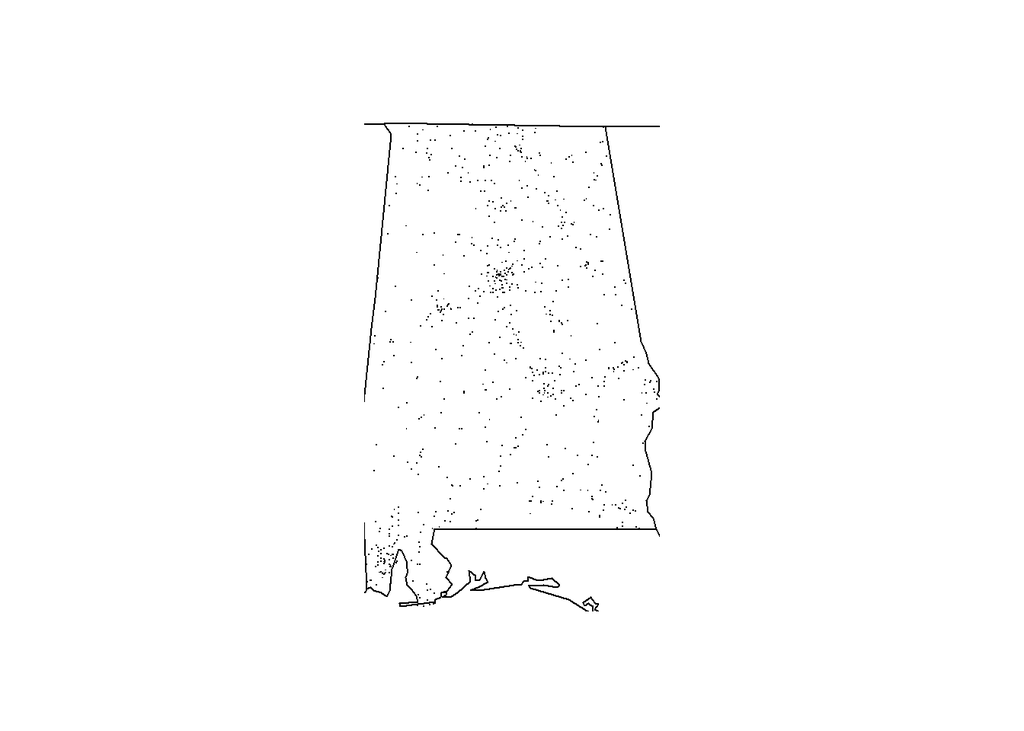

```r
fars_map_state(1, 2014)
```